# Severe weather public health and economic problems

pijokela

24.04.2015

## Synopsis

Storms and other severe weather events can cause both public health and economic problems for communities and municipalities. This analysis will find out which weather effects cause (1) the most public health issues as fatalities and injuries and (2) the most economic problems.

The most health problems are caused by tornados while floods cause the biggest economical problems.

## Data Processing

This section describes how the data was processed with R during the analysis.

Load file from web and unzip it:

```r
# Download data file from internet and store it:
if (!file.exists("stormdata.csv.bz2")) {
  download.file(
    "https://d396qusza40orc.cloudfront.net/repdata%2Fdata%2FStormData.csv.bz2",
    "stormdata.csv.bz2",method="curl")
}

stormdata <- read.csv(bzfile("stormdata.csv.bz2"))

# EVDATA contains upper and lower case letters, convert all to upper case:
stormdata$EVTYPE <- toupper(stormdata$EVTYPE)

# Remove summary rows from dataset, because they are not real storm types:
stormdata <- stormdata[!grepl(".*SUMMARY.*", stormdata$EVTYPE), ]

# Some EVTYPE values have leading spaces, they must be removed:
#install.packages("stringr", dependencies=TRUE)
require(stringr)
stormdata$EVTYPE<-str_trim(stormdata$EVTYPE)
```

The property damage values use a separate column of exponent values. They are translated in to numeric exponents and combined to a single number value.

```r
eval_exp <- function(val, exp) {
  switch(as.character(exp),
         "-"=0, "?"=0, "+"=0,
         "0"=val,
         "1"=10*val,
         "2"=100*val, h=100*val, H=100*val,
         "3"=1000*val, k=1000*val, K=1000*val,
         "4"=10000*val,
         "5"=100000*val,
         "6"=1000000*val, m=1000000*val, M=1000000*val,
         "7"=10000000*val,
         "8"=100000000*val,
         b=1000000000*val, B=1000000000*val, 0)
}

eval_exp_v <- Vectorize(eval_exp)
```

Create a data frame that groups FATALITIES, INJURIES and PROPDMG for each event type in the original dataset:

```r
stormdata$prop_dmg <- eval_exp_v(stormdata$PROPDMG, stormdata$PROPDMGEXP)

fatalitiesByEventTypeUnOrdered <- aggregate(FATALITIES ~ EVTYPE, stormdata, sum)
fatalitiesByEventType <- fatalitiesByEventTypeUnOrdered[order(fatalitiesByEventTypeUnOrdered$EVTYPE),]

fatalitymeanByEventTypeUnOrdered <- aggregate(FATALITIES ~ EVTYPE, stormdata, mean)
fatalitymeanByEventType <- fatalitymeanByEventTypeUnOrdered[order(fatalitymeanByEventTypeUnOrdered$EVTYPE),]

injuriesByEventTypeUnOrdered <- aggregate(INJURIES ~ EVTYPE, stormdata, sum)
injuriesByEventType <- injuriesByEventTypeUnOrdered[order(injuriesByEventTypeUnOrdered$EVTYPE),]

injuriesmeanByEventTypeUnOrdered <- aggregate(INJURIES ~ EVTYPE, stormdata, mean)
injuriesmeanByEventType <- injuriesmeanByEventTypeUnOrdered[order(injuriesmeanByEventTypeUnOrdered$EVTYPE),]

injuriesByEventTypeUnOrdered <- aggregate(INJURIES ~ EVTYPE, stormdata, sum)
injuriesByEventType <- injuriesByEventTypeUnOrdered[order(injuriesByEventTypeUnOrdered$EVTYPE),]

injuriesmeanByEventTypeUnOrdered <- aggregate(INJURIES ~ EVTYPE, stormdata, mean)
injuriesmeanByEventType <- injuriesmeanByEventTypeUnOrdered[order(injuriesmeanByEventTypeUnOrdered$EVTYPE),]

prop_dmg_mean_eventtype_unordered <- aggregate(prop_dmg ~ EVTYPE, stormdata, mean)
prop_dmg_mean_eventtype <- prop_dmg_mean_eventtype_unordered[order(prop_dmg_mean_eventtype_unordered$EVTYPE),]

prop_dmg_sum_eventtype_unordered <- aggregate(prop_dmg ~ EVTYPE, stormdata, sum)

stormdata_by_event_type <- prop_dmg_sum_eventtype_unordered[order(prop_dmg_sum_eventtype_unordered$EVTYPE),]
stormdata_by_event_type$prop_dmg_mean <- prop_dmg_mean_eventtype$prop_dmg
stormdata_by_event_type$fatalities_mean <- fatalitymeanByEventType$FATALITIES
stormdata_by_event_type$fatalities_sum  <- fatalitiesByEventType$FATALITIES
stormdata_by_event_type$injuries_mean <- injuriesmeanByEventType$INJURIES
stormdata_by_event_type$injuries_sum  <- injuriesByEventType$INJURIES
```

## Results

This analysis has two parts in this results section. First we concentrate on healts issues and later on property damage.

### Across the United States, which types of events (as indicated in the EVTYPE variable) are most harmful with respect to population health?

```r
stormdata_fatalities_sorted <- stormdata_by_event_type[order(-stormdata_by_event_type$fatalities_sum),]
stormdata_fatalities_plot <- head(stormdata_fatalities_sorted, n = 10L)
```

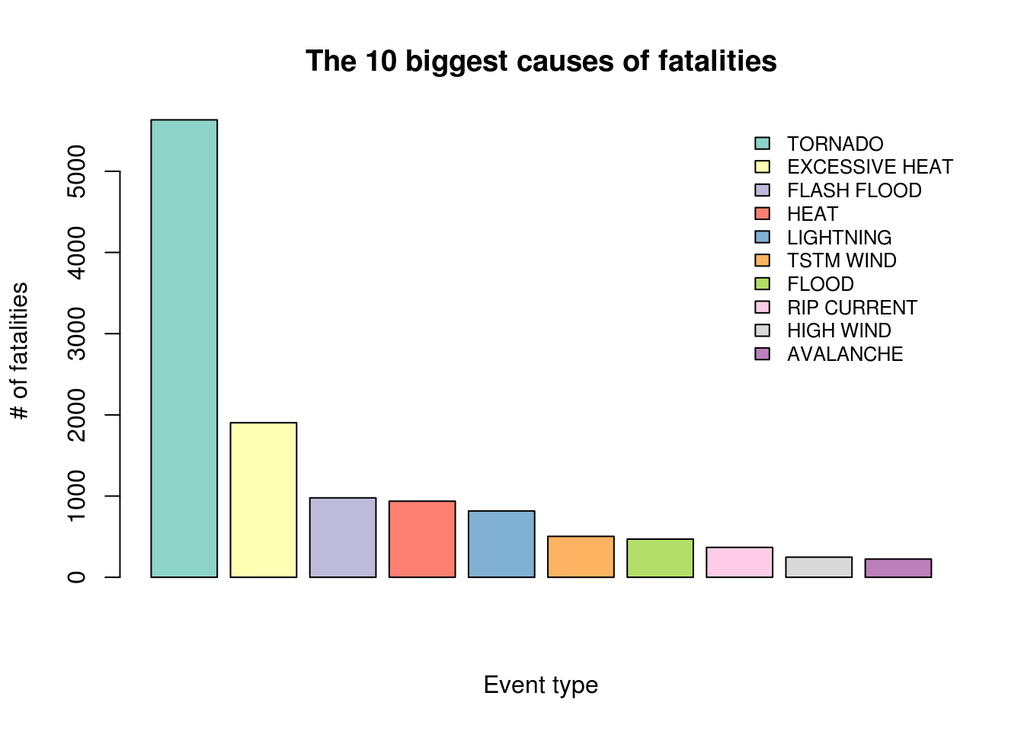

```r
#install.packages("RColorBrewer", dependencies=TRUE)
library(RColorBrewer)
colors10 = brewer.pal(10, "Set3")

barplot(stormdata_fatalities_plot$fatalities_sum, main="The 10 biggest causes of fatalities", xlab="Event type", ylab="# of fatalities", col=colors10)

legend("topright", stormdata_fatalities_plot$EVTYPE, cex=0.8, bty="n", fill=colors10)
```

```r
stormdata_injuries_sorted <- stormdata_by_event_type[order(-stormdata_by_event_type$injuries_sum),]
head(stormdata_injuries_sorted)
```

```
##             EVTYPE     prop_dmg prop_dmg_mean fatalities_mean
## 683        TORNADO  56947380614    938920.079     0.092874101
## 705      TSTM WIND   4493058495     20428.007     0.002291472
## 145          FLOOD 144657709800   5711600.655     0.018557271
## 107 EXCESSIVE HEAT      7753700      4620.799     1.134088200
## 404      LIGHTNING    930379426     59052.963     0.051793082
## 234           HEAT      1797000      2342.894     1.221642764
##     fatalities_sum injuries_mean injuries_sum
## 683           5633    1.50606740        91346
## 705            504    0.03163049         6957
## 145            470    0.26805386         6789
## 107           1903    3.88855781         6525
## 404            816    0.33195811         5230
## 234            937    2.73794003         2100
```

Tornadoes also lead the injuries data.

#### What about EVTYPE groupings?

The data contains many event types where heat is contained in the description. Also, there are other EVTYPE values that are also tornadoes. To make sure that the total fatalities of the HEAT related EVTYPES are not greater than the TORNADO fatalities, we can sum up the EVTYPES that contain these words.

```r
tornado_storm_data <- stormdata_by_event_type[grepl(".*TORNADO.*", stormdata_by_event_type$EVTYPE), ]
sum(tornado_storm_data$fatalities_sum)
```

```
## [1] 5661
```

```r
sum(tornado_storm_data$injuries_sum)
```

```
## [1] 91407
```

```r
heat_storm_data <- stormdata_by_event_type[grepl(".*HEAT.*", stormdata_by_event_type$EVTYPE), ]
sum(heat_storm_data$fatalities_sum)
```

```
## [1] 3138
```

```r
sum(heat_storm_data$injuries_sum)
```

```
## [1] 9224
```

```r
wind_storm_data <- stormdata_by_event_type[grepl(".*WI?ND.*", stormdata_by_event_type$EVTYPE), ]
sum(wind_storm_data$fatalities_sum)
```

```
## [1] 1451
```

```r
sum(wind_storm_data$injuries_sum)
```

```
## [1] 11498
```

From here we can see that even added up, the HEAT types are not as harmful as the TORNADO type.

#### Tornado is most harmful event type with respect to population health

By sorting the data by the total number of injuries by event type we can see that tornadoes also cause the most injuries. So it can be said that the most harmful type of events with respect to population healts is tornado.

### Across the United States, which types of events have the greatest economic consequences?

To find out which event type causes the most economic consequences, we use the property data column in the storm data grouped by event types. To find the biggest economic impact, use head to list top contributors:

```r
stormdata_prop_dmg_sorted <- stormdata_by_event_type[order(-stormdata_by_event_type$prop_dmg),]
stormdata_prop_dmg_plot <- head(stormdata_prop_dmg_sorted, n=10)
```

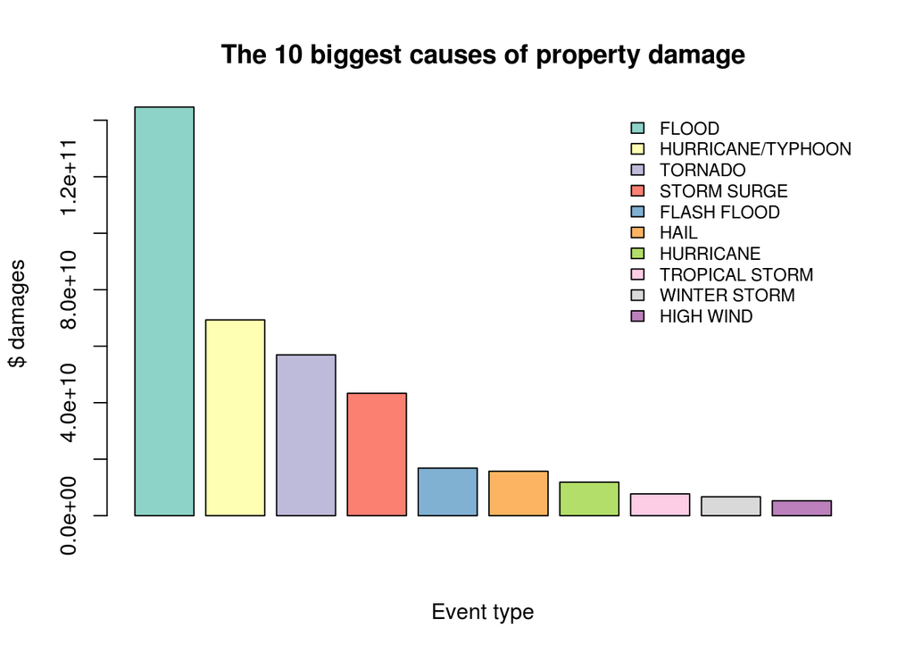

```r
barplot(stormdata_prop_dmg_plot$prop_dmg, main="The 10 biggest causes of property damage", xlab="Event type", ylab="$ damages", col=colors10)

legend("topright", stormdata_prop_dmg_plot$EVTYPE, cex=0.8, bty="n", fill=colors10)
```

#### The most economical problem causing event type is floods

The most property damage causing single EVTYPE is FLOOD. There are also some other EVTYPEs with the word flood in them. Sum these up to find the total amount of flood damages:

```r
flood_storm_data <- stormdata_by_event_type[grepl(".*FLOOD.*", stormdata_by_event_type$EVTYPE), ]
sum(flood_storm_data$prop_dmg)
```

```
## [1] 168212215588
```

```r
sum(tornado_storm_data$prop_dmg)
```

```
## [1] 58603317864
```

```r
sum(wind_storm_data$prop_dmg)
```

```
## [1] 17951213993
```

```r
sum(stormdata_by_event_type$prop_dmg) - sum(flood_storm_data$prop_dmg)
```

```
## [1] 260012652520
```

Comparing these sums shows that even if we group together all events that contain the word wind, the flood damages are still the biggest cause of property damage.